# Practicals — Introduction to Bayesian analysis for medical studies — Solutions to exercise 5

Boris Hejblum

May 15<sup>th</sup> 2019

# Exercise 5: *Post-mortem* analysis of an under-powered randomized trial

The randomized clinical trial *EOLIA* (Combes et al. 2018) evaluated a new treatment for severe acute respiratory distress syndrome (ARDS) by comparing the mortality rate after 60 days among 249 patients randomized between a control group (receiving conventional treatmetn, i.e. mechanical ventilation) and a treatment group receiving extracorporeal membrane oxygenation (ECMO) — the new treatment studied. A frequentist analysis of the data concluded to a Relative Risk of death of 0.76 in the ECMO compared to control (in Intention to Treat), with $CI_{95\%} = [0.55 , 1.04]$ and the associated p-value of $0.09$.

(Goligher et al. 2018) performed a Bayesian re-analysis of these data, further exploring the evidence and how it can be quantified and summarized with a Bayesian approach.

Observed data from the *EOLIA* trial

[output not shown]

1. Write the Bayesian model used by (Goligher et al. 2018)
   *I) Question of interest:*
   *Is the Relative Risk of death under ECMO compared to the conventional mechanical treatment less than one ?*
   *II) Sampling model:*
   *Let $Z_{control}$ be the number of death in the control group, and $zecmo$ the number of death in the ECMO group*
   $$Z_{control} \sim Binomial(p_c, 125)$$
   $$Z_{ecmo} \sim Binomial(RR\times p_c, 124)$$
   *III) Priors:*
   $$p_c\sim U_{[0,1]}$$
   $$log(RR)\sim U_{[-35,35]}$$
   *NB:* One can also define a sampling model at the individual level:
   Let $Y_{control_i}$ be a binary variable indicating whether the patient $i$ from the control group died before 60 days, and $Y_{ecmo_i}$ a similar variable for patient from the ecmo group.
   $$Y_{control_i} \overset{iid}{\sim} Bernoulli(p_c)$$
   $$Y_{ecmo_i} \overset{iid}{\sim} Bernoulli(RR\times p_c)$$
2. Write the corresponding BUGS model

   ```
   # Population model
   model{

     # Sampling model
     zcontrol~dbin(pc, ncontrol)
     zecmo~dbin(RR*pc, necmo)

     # Prior
     logRR~dunif(-35,35)
     pc~dunif(0,1) #probability of death in the control group

     # Reparametrizations
     RR <- exp(logRR)
   }
   ```

   ```
   # Individual model
   model{

     # Sampling model
     for (i in 1:ncontrol){
       ycontrol[i]~dbern(pc)
     }
     for (i in 1:necmo){
       yecmo[i]~dbern(RR*pc)
     }

     # Prior
     logRR~dunif(-35,35)
     pc~dunif(0,1) #probability of death in the control group

     # Reparametrizations
     RR <- exp(logRR)
   }
   ```

3. First create two binary data vectors `ycontrol` and `yecmo`, that are either `1` or `0`, to encode the observations from the data table above. Then uses the `jags.model()` and `coda.samples()` to replicate the estimation from (Goligher et al. 2018) (**ProTip:** use the function `window()` to remove the burn-in observation from the output of the `coda.samples` funtion.)

   ```r
   # individual data
   ycontrol <- c(rep(0, 125 - 57), rep(1, 57))
   yecmo <- c(rep(0, 124 - 44), rep(1, 44))

   # Sampling
   library(rjags)
   goligher_jags_indiv <- jags.model(file = "goligherBUGSmodel_indiv.txt", data = list(ycontrol = ycontrol,
       ncontrol = length(ycontrol), yecmo = yecmo, necmo = length(yecmo)), n.chains = 3)
   res_goligher_indiv <- coda.samples(model = goligher_jags_indiv, variable.names = c("pc",
       "RR"), n.iter = 20000)

   # Postprocessing
   res_goligher_burnt_indiv <- window(res_goligher_indiv, start = 5001)  # remove burn-in for Markov chain convergence

   # population data
   zcontrol <- 57
   zecmo <- 44
   goligher_jags_pop <- jags.model(file = "goligherBUGSmodel_pop.txt", data = list(zcontrol = zcontrol,
       ncontrol = 125, zecmo = zecmo, necmo = 124), n.chains = 3)
   res_goligher_pop <- coda.samples(model = goligher_jags_pop, variable.names = c("pc",
       "RR"), n.iter = 20000)

   # Postprocessing
   res_goligher_burnt_pop <- window(res_goligher_pop, start = 5001)  # remove burn-in for Markov chain convergence
   ```

4. Check the convergence, and then comment the estimate results (**ProTip:** look at the effective sample size with the `effectiveSize()` `R` function).

   ```r
   effectiveSize(res_goligher_burnt_pop)
   ```

   ```
   ##       RR       pc
   ## 12900.25 12537.90
   ```

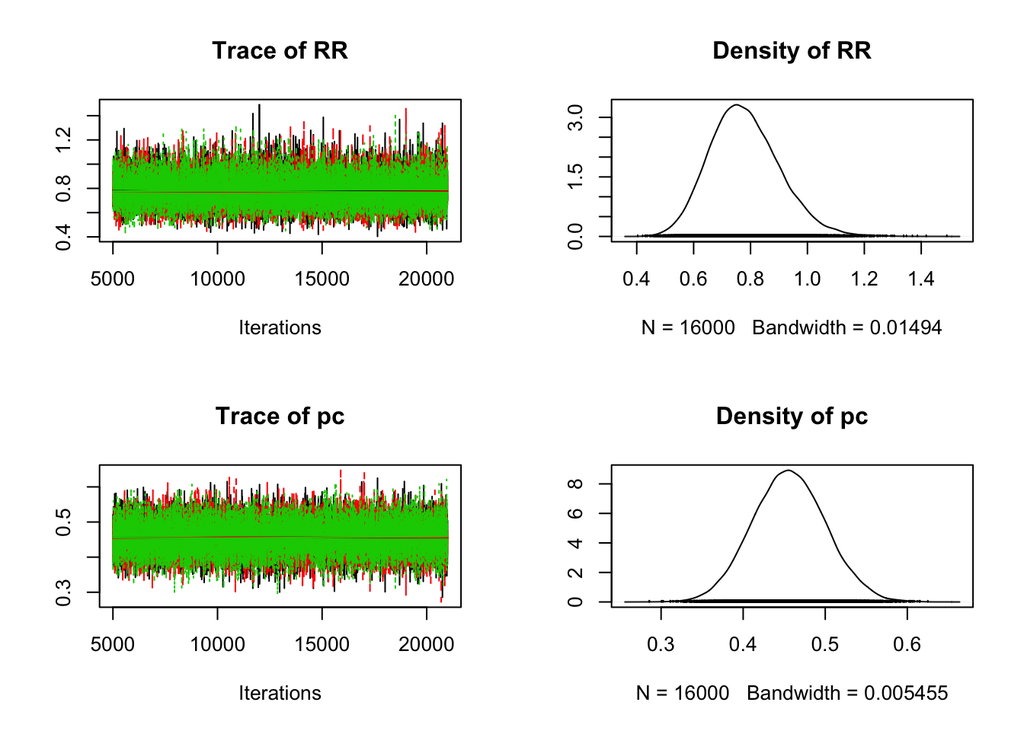

   ```r
   plot(res_goligher_burnt_pop)
   ```

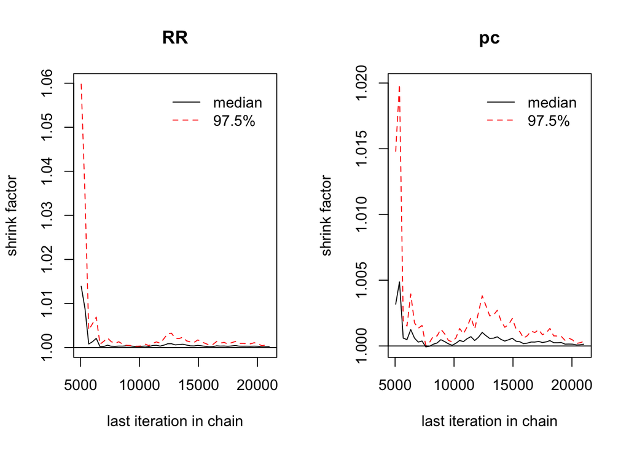

   ```r
   gelman.plot(res_goligher_burnt_pop)
   ```

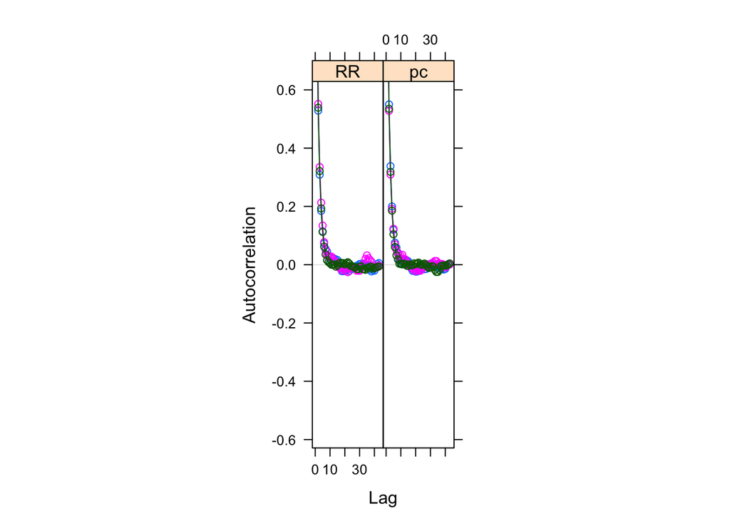

   ```r
   acfplot(res_goligher_burnt_pop)
   ```

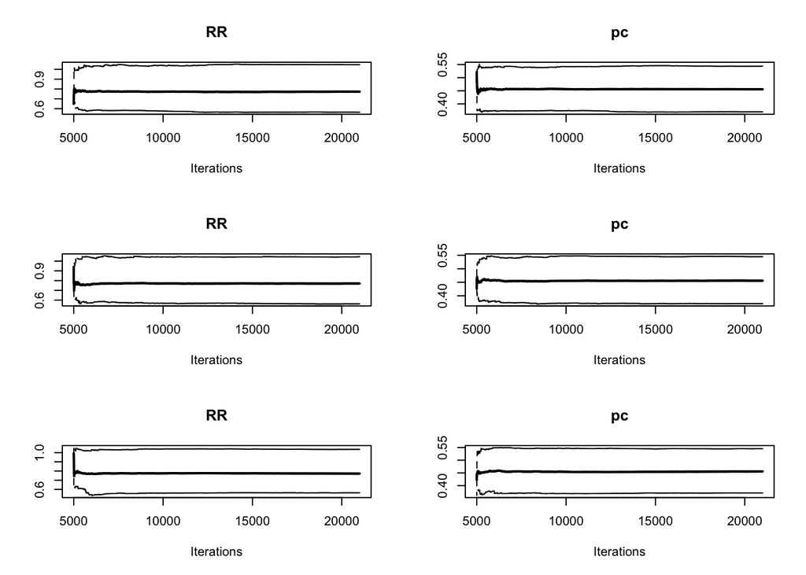

   ```r
   par(mfrow = c(3, 2))
   cumuplot(res_goligher_burnt_pop, ask = FALSE, auto.layout = FALSE)
   ```

   ```r
   par(mfrow = c(1, 1))

   summary(res_goligher_burnt_pop)
   ```

   ```
   ##
   ## Iterations = 5001:21000
   ## Thinning interval = 1
   ## Number of chains = 3
   ## Sample size per chain = 16000
   ##
   ## 1. Empirical mean and standard deviation for each variable,
   ##    plus standard error of the mean:
   ##
   ##      Mean      SD  Naive SE Time-series SE
   ## RR 0.7799 0.12276 0.0005603      0.0010815
   ## pc 0.4561 0.04444 0.0002028      0.0003972
   ##
   ## 2. Quantiles for each variable:
   ##
   ##      2.5%    25%    50%    75%  97.5%
   ## RR 0.5625 0.6940 0.7718 0.8572 1.0412
   ## pc 0.3704 0.4257 0.4558 0.4860 0.5446
   ```

   ```r
   summary(res_goligher_burnt_indiv)
   ```

   ```
   ##
   ## Iterations = 5001:21000
   ## Thinning interval = 1
   ## Number of chains = 3
   ## Sample size per chain = 16000
   ##
   ## 1. Empirical mean and standard deviation for each variable,
   ##    plus standard error of the mean:
   ##
   ##      Mean      SD  Naive SE Time-series SE
   ## RR 0.7775 0.12214 0.0005575      0.0010824
   ## pc 0.4570 0.04408 0.0002012      0.0003817
   ##
   ## 2. Quantiles for each variable:
   ##
   ##      2.5%    25%    50%    75%  97.5%
   ## RR 0.5633 0.6918 0.7684 0.8544 1.0401
   ## pc 0.3705 0.4272 0.4570 0.4867 0.5436
   ```

   ```r
   # shortest 95% Credibility interval:
   HDInterval::hdi(res_goligher_burnt_pop)
   ```

   ```
   ##              RR        pc
   ## lower 0.5480636 0.3694435
   ## upper 1.0223563 0.5435626
   ## attr(,"credMass")
   ## [1] 0.95
   ```

   ```r
   # posterior porbability of RR <1:
   mean(c(sapply(res_goligher_burnt_pop, "[", , 1)) < 1)
   ```

   ```
   ## [1] 0.9546875
   ```

5. Change to a more informative *prior* using a Gaussian distribution for the log(RR), centered on log(0.78) and with a standard deviation of 0.15 in the log(RR) scale (i.e. a precision of $\approx 45$). Comment the results. Try out other *prior* distributions.

   ```
    logRR~dnorm(log(0.78), 45)
   ```

# Bibliography

Combes, Alain, David Hajage, Gilles Capellier, Alexandre Demoule, Sylvain Lavoué, Christophe Guervilly, Daniel Da Silva, et al. 2018. “Extracorporeal Membrane Oxygenation for Severe Acute Respiratory Distress Syndrome.” *New England Journal of Medicine* 378 (21): 1965–75. https://doi.org/10.1056/NEJMoa1800385.

Goligher, Ewan C., George Tomlinson, David Hajage, Duminda N. Wijeysundera, Eddy Fan, Peter Jüni, Daniel Brodie, Arthur S. Slutsky, and Alain Combes. 2018. “Extracorporeal Membrane Oxygenation for Severe Acute Respiratory Distress Syndrome and Posterior Probability of Mortality Benefit in a Post Hoc Bayesian Analysis of a Randomized Clinical Trial.” *JAMA* 320 (21): 2251. https://doi.org/10.1001/jama.2018.14276.